# Introduction to Bayesian Disease Measurement for Health Scientists - Day 1

CA18208 HARMONY Larissa Training School 2024 - https://harmony-net.eu/

Eleftherios Meletis  
Polychronis Kostoulas

2024-04-22

# Bayesian Statistics

In this session we’ll see how we can estimate a probability of interest but in a Bayesian framework, i.e. using Bayes theorem.

Bayes’ theorem - P(A|B) = P(B|A)*P(A)/P(B)

Components

- P(A|B): Prob of event A occurring given that B is true - Posterior probability
- P(B|A): Prob of event B occurring given that A is true - Likelihood ~ function of A
- P(A): Prob of event A occurring - Prior probability
- P(B): Prob of event B occurring - Marginal probability ~ sum over all possible values of A

# What we usually see/use

- theta: parameter of interest | y: observed data}
- P(theta|y) = P(y|theta) * P(theta)/P(y)

Where:

- P(theta): Prior probability of parameter(s) of interest;
- P(y|theta): Likelihood of the data given the parameters value(s)
- P(theta|y): Posterior probability of parameter(s) of interest given the data and the prior

# Bayesian Inference - Summary & Example

To estimate the posterior distribution P(theta|y) we need to:

- Specify the Prior distribution: P(theta)
- Define the Likelihood of the data: P(y|theta)

# Example 1

Hemophilia is a disease that exhibits X-chromosome-linked recessive inheritance. Consider a woman who has an affected brother, which implies that her mother must be a carrier of the hemophilia gene. We are also told that her father is not affected. Suppose she has two sons, neither of whom is affected.

- The unknown quantity of interest is the state of the woman.

# Exercise 1: Bayesian apparent prevalence (ap) estimation

y out of n individuals test positive. Estimate the apparent prevalence in a Bayesian framework.

- Parameter of interest: ap - [0,1]
- Data: n tested, y positive
- Prior distribution for ap: ap ~ Beta(a,b)
- Likelihood: y ~ Binomial(n,ap)

# Let’s write our first JAGS model

```r
ap_model <-
  'model {

  # Define likelihood distribution of the data
  # JAGS Binomial distribution Arguments: p, n

  y ~ dbin(ap,n)

  # Specify prior distribution for par of interest
  # Uniform (non-informative) prior distribution
  ap ~ dbeta(1, 1)

  #data# n, y
  #monitor# ap
  #inits# ap
  }
  '
```

# Let’s run our first JAGS model

```r
# Call JAGS
library(runjags)

# Provide Data
n = 40
y = 12
```

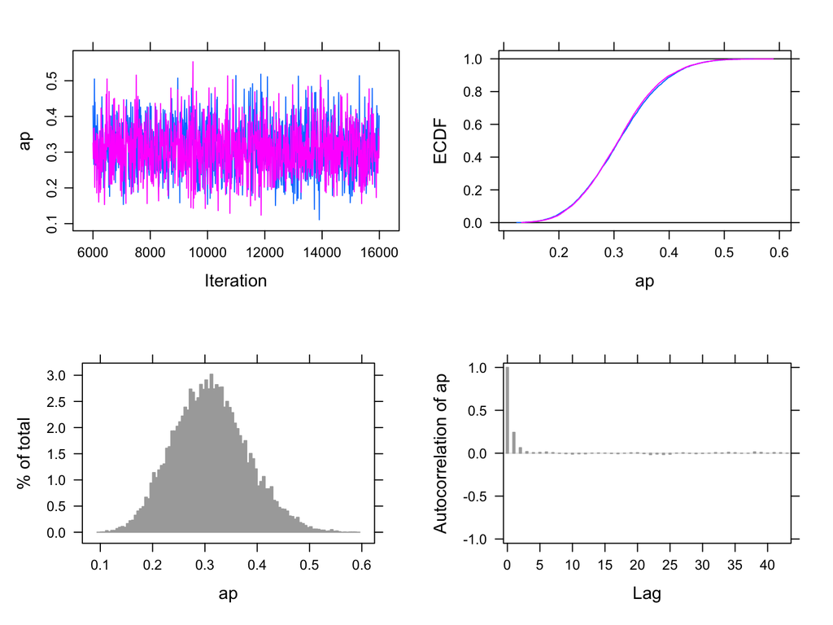

```r
# Initial values for par of interest

ap <- list(chain1=0.05, chain2=0.95)


# Run the model
results <- run.jags(ap_model, n.chains=2,
                    burnin=5000, sample=10000)

# View results

# Plot results
plot(results)
```

```r
# Print results
summary(results)
```

```
##      Lower95    Median   Upper95      Mean         SD Mode        MCerr MC%ofSD
## ap 0.1778629 0.3082497 0.4517272 0.3106065 0.07025252   NA 0.0006366397     0.9
##    SSeff       AC.10     psrf
## ap 12177 -0.00986609 1.000258
```

# Exercise 1 - Practical

- What if you tested 4000 individuals (n=4000) and 1200 tested positive (y=1200)?
- What if you have prior information on ap?

# Exercise 2: Bayesian true prevalence (tp) estimation

Assuming the absence of a perfect test we do not know how many individuals are truly positive/negative.

Instead we know that n individuals are tested with an imperfect test and y have a positive result.

- Apparent/True prevalence: ap/tp
- Sensitivity: Se
- Specificity: Sp
- ap = P(T+) = P(T + & D+) + P(T+ & D-) = P(D+) * P(T+|D+) + P(D-) * P(T+|D-) =>
- ap = tp * Se + (1 - tp) * (1 - Sp)

# Create a JAGS model for true prevalence estimation

- Parameters of interest - tp, Se, Sp

Prior distributions

Data: n tested, y positive

- Likelihood: y ~ Binomial(n,ap),
- ap = tp * Se + (1 - tp) * (1 - Sp)

# Write JAGS model

```r
tp_model <-
  'model {
  y ~ dbin(ap,n)
  ap <- tp*Se + (1-tp)*(1-Sp)

  # Uniform (non-informative) prior distribution
  tp ~ dbeta(1,1)
  # Informative priors for Se and Sp
  Se ~ dbeta(25.4, 3.4)
  Sp ~ dbeta(95, 5)

  #data# n, y
  #monitor# tp, Se, Sp
  #inits# tp, Se, Sp
  }
  '
```

# Let’s run our JAGS model

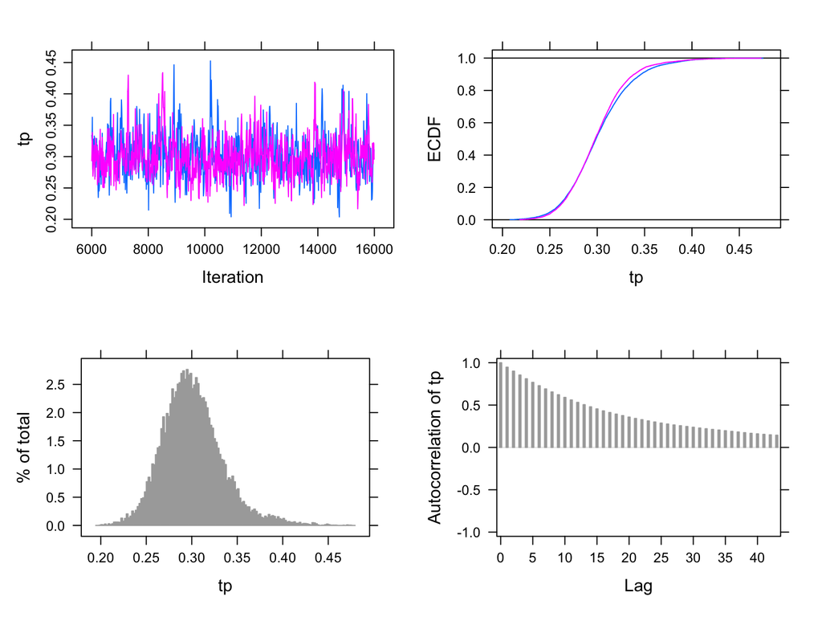

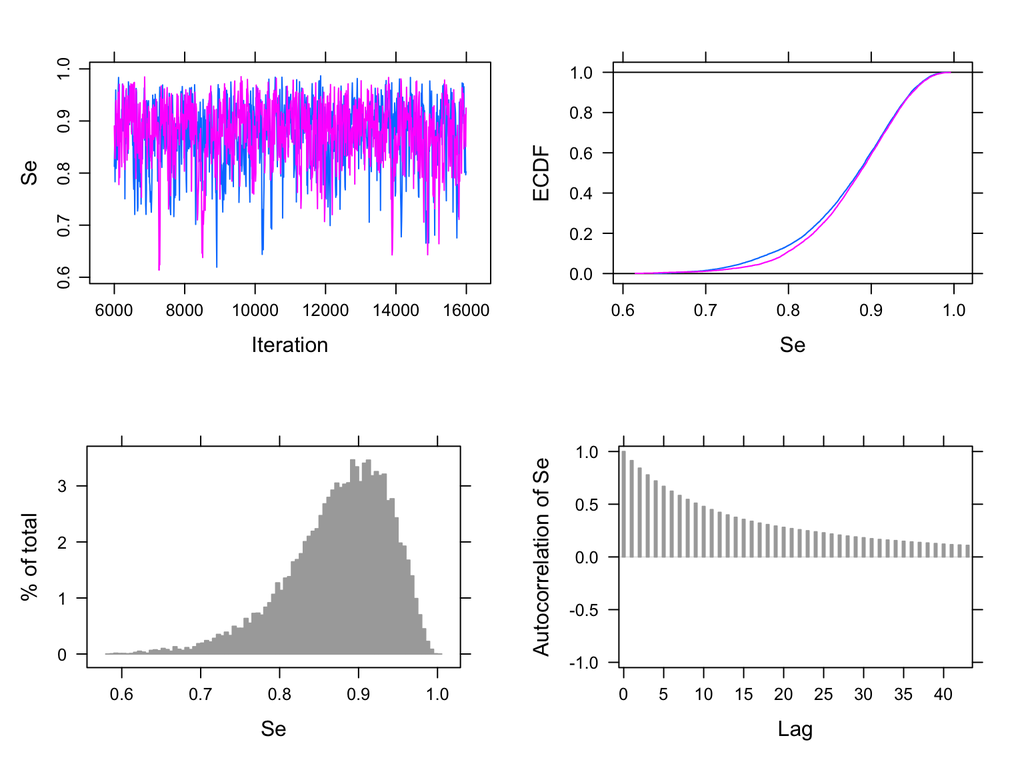

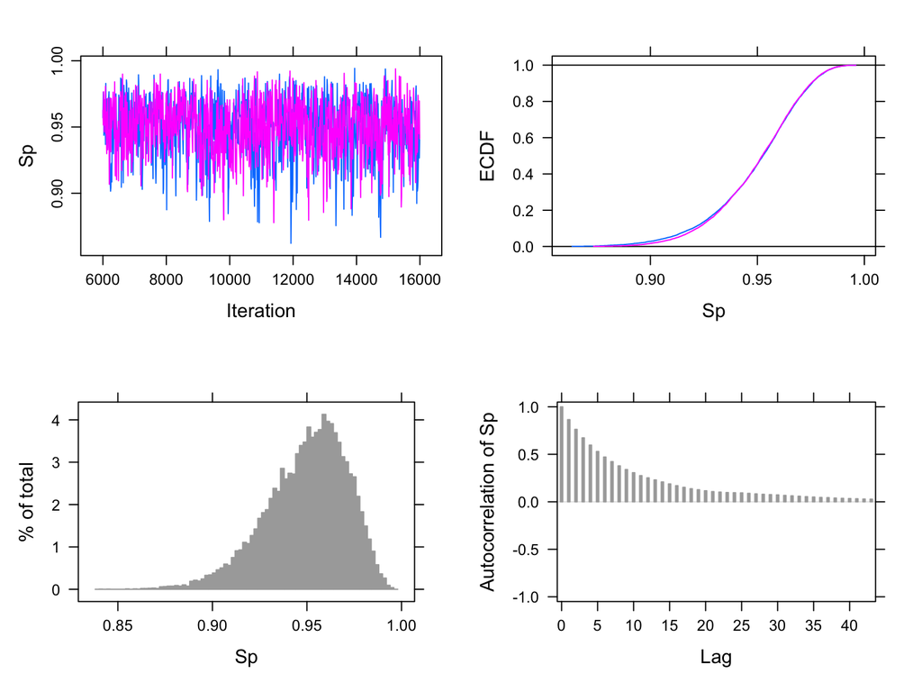

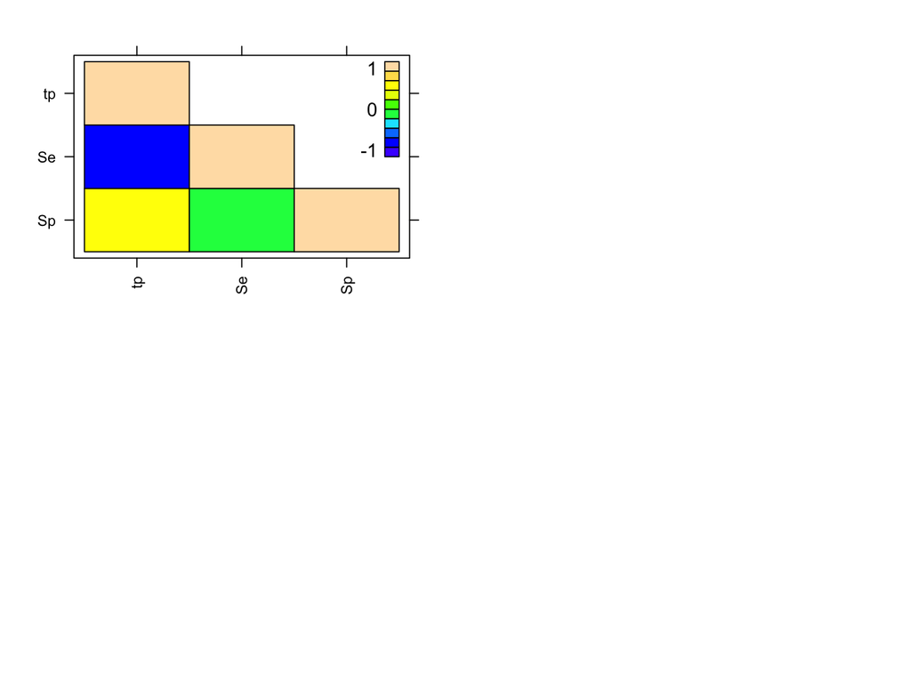

```r
# Call JAGS
library(runjags)
# Provide Data
n = 4072
y = 1210
# Initial values for pars of interest
tp <- list(chain1=0.05, chain2=0.95)
Se <- list(chain1=0.05, chain2=0.95)
Sp <- list(chain1=0.05, chain2=0.95)

# Run the model
results <- run.jags(tp_model, n.chains=2,
                    burnin=5000, sample=10000)
## View results
# Plot results
plot(results) # Click backwards to view all plots
```

```r
# Print results
summary(results)
```

```
##      Lower95    Median   Upper95      Mean         SD Mode        MCerr MC%ofSD
## tp 0.2387222 0.2982212 0.3716066 0.3009740 0.03347328   NA 0.0014568717     4.4
## Se 0.7476448 0.8849868 0.9818542 0.8752047 0.06412940   NA 0.0023730695     3.7
## Sp 0.9070314 0.9524097 0.9866786 0.9496836 0.02143407   NA 0.0005957095     2.8
##    SSeff     AC.10     psrf
## tp   528 0.5891826 1.004038
## Se   730 0.4768172 1.001632
## Sp  1295 0.3060852 1.000415
```

# Exercise 2 - Practical

- What if you had no prior information at all on Se,Sp?
- What if the sample size is n=40, y=12?

# Ok for today? - Any questions?